# Лабораторная работа №1

YASINOVSKY/OSTAPENKO

19 декабря 2016 г

# Задание 1

```r
mean1 = mean(rexp(n=200))
sd1 = sd(rexp(n=200))
```

exp.0.1

```r
mean2 = mean(rexp(n=200, rate=0.1))
sd2 = sd(rexp(n=200, rate=0.1))
```

exp.0.5

```r
mean3 = mean(rexp(n=200, rate=0.5))
sd3 = sd(rexp(n=200, rate=0.5))
```

exp.5

```r
mean4 = mean(rexp(n=200, rate=5))
sd4 = sd(rexp(n=200, rate=5))
```

exp.10.

```r
mean5 = mean(rexp(n=200, rate=10))
sd5 = sd(rexp(n=200, rate=10))
```

Использование функции hist()

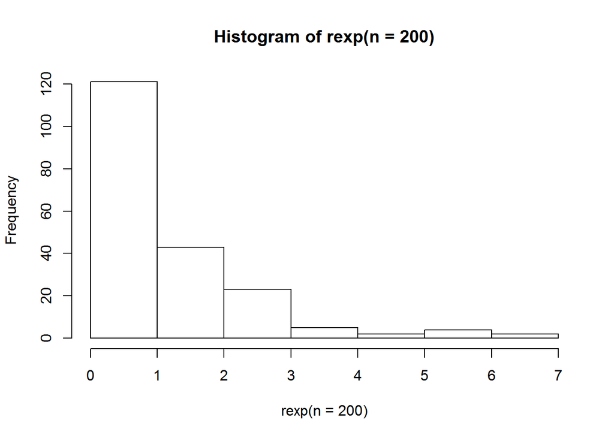

```r
hist(rexp(n=200))
```

Использование функции plot()

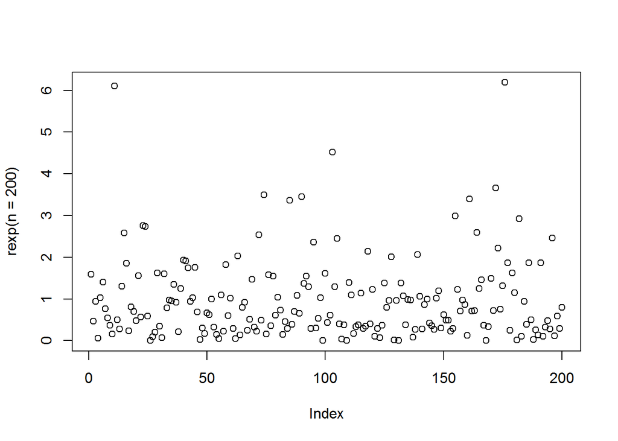

```r
plot(rexp(n=200))
```

Использование функции plot() для построения диаграммы рассеяния

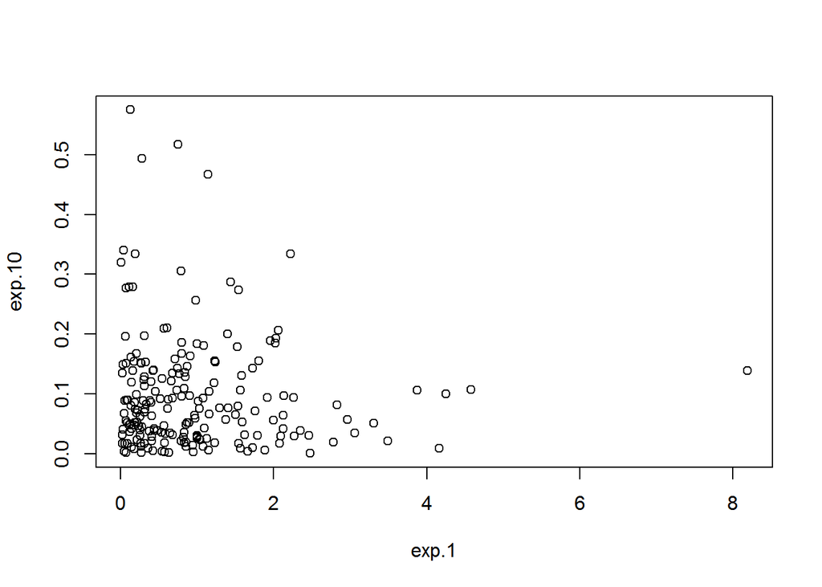

```r
exp.1 = rexp(n=200)
exp.10 = rexp(n=200, rate=10)
plot(exp.1, exp.10)
```

Создалий вектор, содержащий средние значения каждого из 5 полученных ранее распределений в порядке их создания.

```r
exp.means <- rep(c(mean(rexp(n=200)),mean(rexp(n=200, rate=0.1)),mean(rexp(n=200, rate=0.5)),mean(rexp(n=200, rate=5)),mean(rexp(n=200, rate=10))),times=40)
```

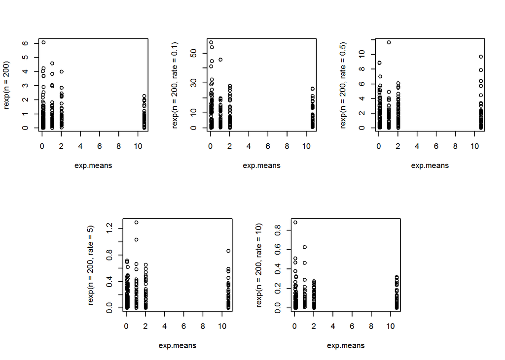

```r
layout(matrix(c(1,1,2,2,3,3,0,4,4,5,5,0),nrow = 2, byrow = TRUE))
plot(exp.means, rexp(n=200))
plot(exp.means, rexp(n=200, rate=0.1))
plot(exp.means, rexp(n=200, rate=0.5))
plot(exp.means, rexp(n=200, rate=5))
plot(exp.means, rexp(n=200, rate=10))
```

```r
exp.means_2 <- rep(c(sd(rexp(n=200)),sd(rexp(n=200, rate=0.1)),sd(rexp(n=200, rate=0.5)),sd(rexp(n=200, rate=5)),sd(rexp(n=200, rate=10))),times=40)
```

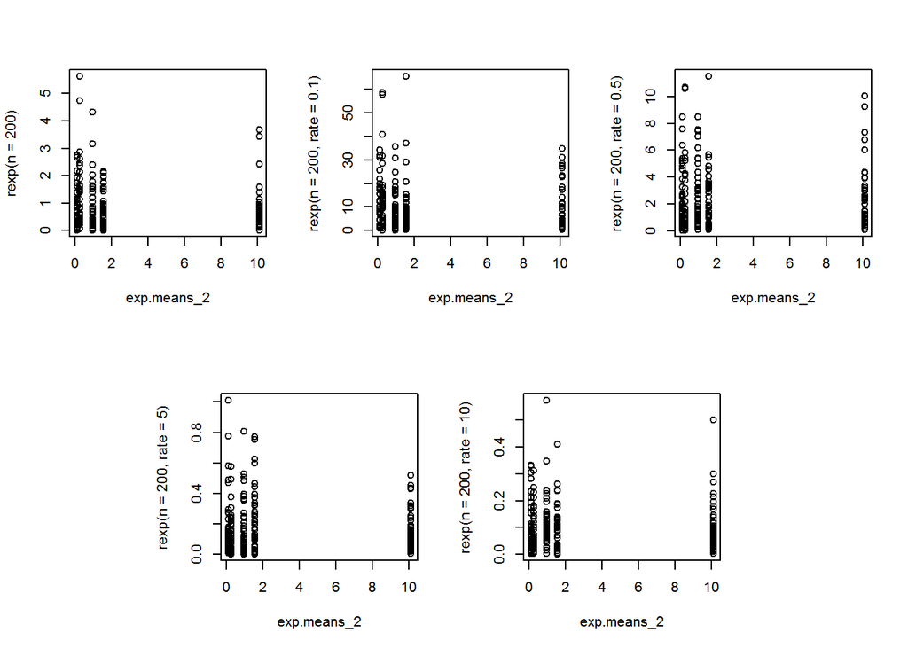

```r
layout(mat=matrix(c(1,1,2,2,3,3,0,4,4,5,5,0),nrow = 2, byrow = TRUE))
plot(exp.means_2, rexp(n=200))
plot(exp.means_2, rexp(n=200, rate=0.1))
plot(exp.means_2, rexp(n=200, rate=0.5))
plot(exp.means_2, rexp(n=200, rate=5))
plot(exp.means_2, rexp(n=200, rate=10))
```

Вектор с пятью средними относительно вектора с пятью стандартными отклонениями.

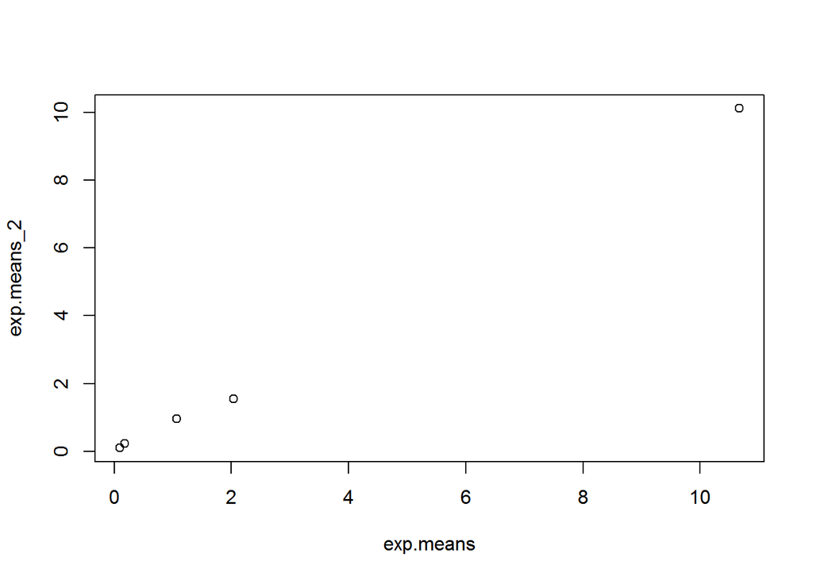

```r
plot(exp.means,exp.means_2)
```

# Задание 2

Генерация 1 млн. 100 тысяч числе из стандартного экспоненциального распределения и сохранил их в вектор huge.exp.1. Получил среднее и стандартное отклонение.

```r
mean(rexp(n=1100000))
```

```
## [1] 1.000013
```

```r
sd(rexp(n=1100000))
```

```
## [1] 0.9981232
```

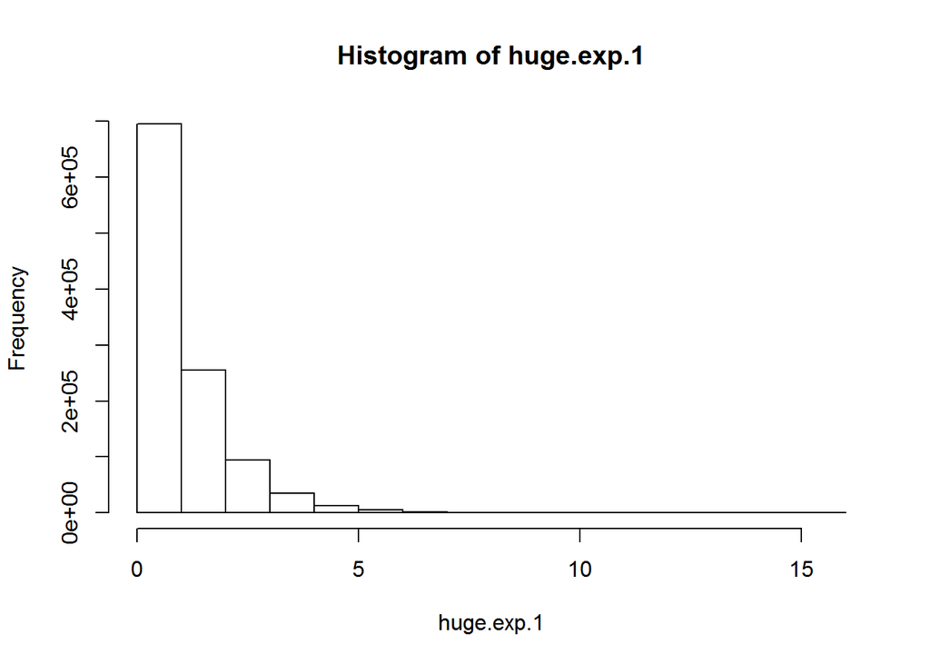

```r
huge.exp.1 <- rexp(n=1100000)
hist(huge.exp.1)
```

Получите среднее всех чисел из huge.exp.1 строго больших 1. Для проверки выборки может потребоваться новый вектор.

```r
mean(huge.exp.1[huge.exp.1>1])
```

```
## [1] 2.000823
```

Получил матрица huge.exp.1.mat, содержащую 1100 строк и 1000 колонок. Построил гистограммы, использовав полученную матрицу.

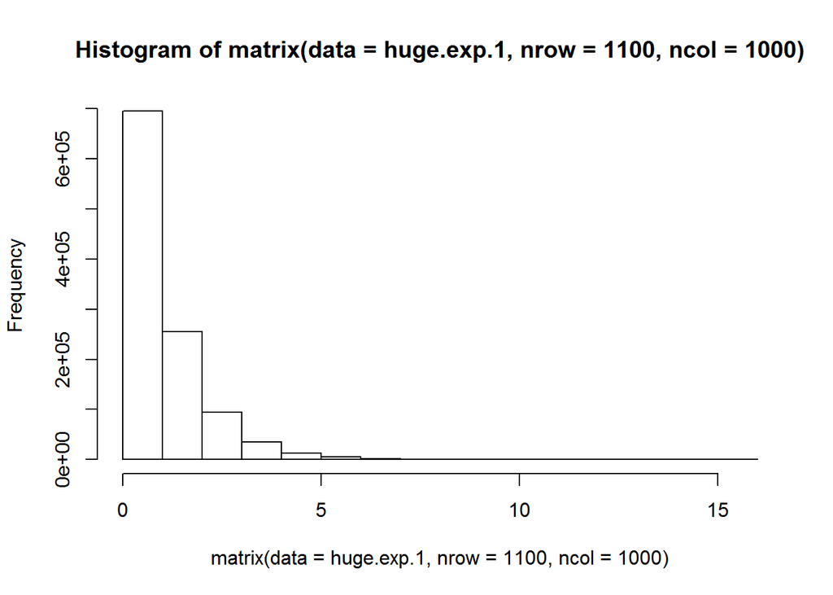

```r
hist(matrix(data=huge.exp.1, nrow=1100, ncol=1000))
```

Рассчитал среднее 137-й колонки из huge.exp.1.mat.

```r
mean(matrix(data=huge.exp.1, nrow=1100, ncol=1000)[,137])
```

```
## [1] 1.00526
```

Найдите среднее всей 1000 колонок и сохраните их в вектор. Отобразите диаграмму средних зннчений колонок. Объясните почему форма диаграммы отличается от виденных ранее.

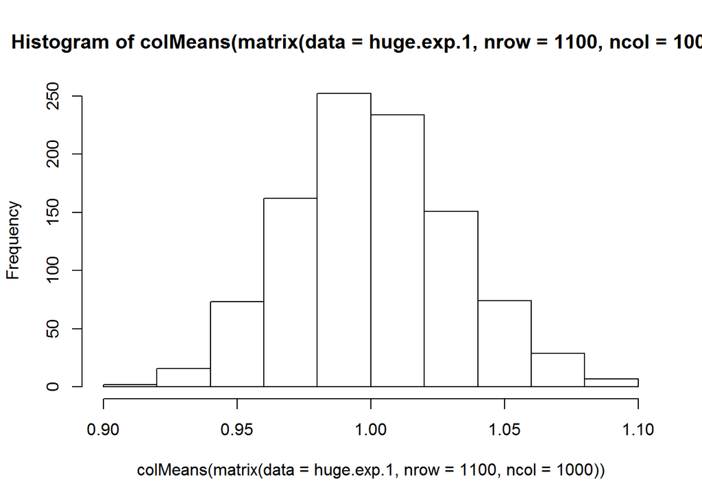

```r
hist(colMeans(matrix(data=huge.exp.1, nrow=1100, ncol=1000)))
```

Рассчитайте квадрат каждого значения из huge.exp.1 и найдите среднее и стандартное отклонение полученного вектора квадратов. Объясните отличие от соответствующих показателей вектора huge.exp.1. Вам может помочь формула, по которой R рассчитывает стандартное отклонение: sqrt(sum((x - mean(x))^2) / (n - 1)).

```r
mean(huge.exp.1**2)
```

```
## [1] 2.001143
```

```r
sd(huge.exp.1**2)
```

```
## [1] 4.464113
```